# Social Deprivation Index

[The social deprivation index (SDI)](https://www.graham-center.org/maps-data-tools/social-deprivation-index.html) is an effort to generate a scoring system of socioeconomic factors using US census data from the American Community Survey. The final SDI is a composite measure of percent living in poverty, percent with less than 12 years of education, percent single-parent households, the percentage living in rented housing units, the percentage living in the overcrowded housing unit, percent of households without a car, and percentage nonemployed adults under 65 years of age. For more details please see the webpage link.

In this webpage we will explore the SDI variable by start location and determine which summary statistic to use to coalece by neighborhood.

## Load Data

```r
citibike_df = read_csv("../citibike_clean/citibike_clean.csv")

head(citibike_df) |>
  knitr::kable()
```

| bikeid | user_type | gender | age | start_time | stop_time | start_station_latitude | start_station_longitude | end_station_latitude | end_station_longitude | start_station_id | start_station_name | start_zipcode | start_uhf34_neighborhood | end_station_id | end_station_name | end_zipcode | end_uhf34_neighborhood | start_sdi_score | start_percent_overweight | start_aq | end_sdi_score | end_percent_overweight | end_aq | end_borough | start_borough |
| --- | --- | --- | --- | --- | --- | --- | --- | --- | --- | --- | --- | --- | --- | --- | --- | --- | --- | --- | --- | --- | --- | --- | --- | --- | --- |
| 39213 | Subscriber | Male | 51 | 2019-09-01 00:00:01 | 2019-09-01 00:05:29 | 40.73056 | -73.97398 | 40.73222 | -73.98166 | 3733 | Avenue C & E 18 St | 10009 | Union Square, Lower Manhattan | 504 | 1 Ave & E 16 St | 10009 | Union Square, Lower Manhattan | 88 | 40.5 | 8.67 | 88 | 40.5 | 8.67 | Manhattan | Manhattan |
| 21257 | Customer | Unknown | 50 | 2019-09-01 00:00:04 | 2019-09-01 00:19:09 | 40.68292 | -73.99318 | 40.69308 | -73.97179 | 3329 | Degraw St & Smith St | 11217 | Downtown Heights Slope | 270 | Adelphi St & Myrtle Ave | 11238 | Bedford Stuyvesant Crown Heights | 74 | 50.8 | 7.44 | 70 | 62.9 | 6.61 | Brooklyn | Brooklyn |
| 15242 | Customer | Unknown | 50 | 2019-09-01 00:00:07 | 2019-09-01 00:21:40 | 40.78473 | -73.96962 | 40.76585 | -73.98691 | 3168 | Central Park West & W 85 St | 10024 | Upper West Side | 423 | W 54 St & 9 Ave | 10019 | Chelsea Village | 41 | 43.4 | 7.38 | 63 | 38.1 | 10.02 | Manhattan | Manhattan |
| 32094 | Subscriber | Male | 27 | 2019-09-01 00:00:12 | 2019-09-01 00:10:26 | 40.74620 | -73.98856 | 40.76030 | -73.99884 | 486 | Broadway & W 29 St | 10019 | Chelsea Village | 478 | 11 Ave & W 41 St | 10018 | Chelsea Village | 63 | 38.1 | 10.02 | 65 | 38.1 | 10.02 | Manhattan | Manhattan |
| 28271 | Customer | Unknown | 50 | 2019-09-01 00:00:16 | 2019-09-01 00:08:19 | 40.70201 | -73.92377 | 40.70624 | -73.93387 | 3775 | Suydam St & Knickerbocker Ave | 11237 | Williamsburg Bushwick | 3771 | McKibbin St & Bogart St | 11206 | Williamsburg Bushwick | 98 | 61.8 | 7.50 | 100 | 61.8 | 7.50 | Brooklyn | Brooklyn |
| 39424 | Customer | Unknown | 50 | 2019-09-01 00:00:17 | 2019-09-01 00:08:27 | 40.70201 | -73.92377 | 40.70624 | -73.93387 | 3775 | Suydam St & Knickerbocker Ave | 11237 | Williamsburg Bushwick | 3771 | McKibbin St & Bogart St | 11206 | Williamsburg Bushwick | 98 | 61.8 | 7.50 | 100 | 61.8 | 7.50 | Brooklyn | Brooklyn |

## Summary Statistics

```r
citibike_df |>
  summarise(
    mean_sdi = round(mean(start_sdi_score, na.rm = TRUE), 1),
    sd_sdi = round(sd(start_sdi_score, na.rm = TRUE), 1),
    median_sdi = round(median(start_sdi_score, na.rm = TRUE), 1),
    q1_sdi = round(quantile(start_sdi_score, 0.25, na.rm = TRUE), 1),
    q3_sdi = round(quantile(start_sdi_score, 0.75, na.rm = TRUE), 1),
    iqr_sdi = round(IQR(start_sdi_score, na.rm = TRUE), 1),
    max_sdi = round(max(start_sdi_score, na.rm = TRUE), 1),
    min_sdi = round(min(start_sdi_score, na.rm = TRUE), 1)
  )|>
  pivot_longer(
    cols = c("mean_sdi", "sd_sdi", "median_sdi", "q1_sdi", "q3_sdi", "iqr_sdi", "max_sdi", "min_sdi"),
    names_to = "Statistic",
    values_to = "Value"
  )|>
  knitr::kable()
```

| Statistic | Value |
| --- | --- |
| mean_sdi | 64.9 |
| sd_sdi | 21.6 |
| median_sdi | 63.0 |
| q1_sdi | 49.0 |
| q3_sdi | 88.0 |
| iqr_sdi | 39.0 |
| max_sdi | 100.0 |
| min_sdi | 26.0 |

Since SDI score is on the zipcode level, we next decide if mean or median is the better way to iterate across neighborhoods.

```r
citibike_df |>
  group_by(start_uhf34_neighborhood) |>
  summarise(
    mean_sdi = mean(start_sdi_score, na.rm = TRUE),
    median_sdi = median(start_sdi_score, na.rm = TRUE),
     max_sdi = round(max(start_sdi_score, na.rm = TRUE), 1),
    min_sdi = round(min(start_sdi_score, na.rm = TRUE), 1)
  )|>
  knitr::kable()
```

| start_uhf34_neighborhood | mean_sdi | median_sdi | max_sdi | min_sdi |
| --- | --- | --- | --- | --- |
| Bedford Stuyvesant Crown Heights | 83.89027 | 83 | 97 | 70 |
| Bensonhurst Bay Ridge | 66.00000 | 66 | 66 | 66 |
| Central Harlem Morningside Heights | 96.12366 | 97 | 98 | 95 |
| Chelsea Village | 58.10703 | 63 | 70 | 37 |
| Coney Island Sheepshead Bay | 78.00000 | 78 | 78 | 78 |
| Downtown Heights Slope | 71.09194 | 74 | 97 | 47 |
| East Flatbush Flatbush | 88.00000 | 88 | 88 | 88 |
| East Harlem | 100.00000 | 100 | 100 | 100 |
| East New York | 98.57200 | 99 | 99 | 97 |
| Greenpoint | 78.31831 | 88 | 88 | 61 |
| Kingsbridge Riverdale | 92.00000 | 92 | 92 | 92 |
| Long Island City Astoria | 78.60394 | 76 | 85 | 62 |
| Ridgewood Forest Hills | 75.00000 | 75 | 75 | 75 |
| Sunset Park | 95.00000 | 95 | 95 | 95 |
| Union Square, Lower Manhattan | 72.17706 | 88 | 97 | 30 |
| Upper East Side Gramercy | 40.15412 | 42 | 50 | 26 |
| Upper West Side | 50.47311 | 43 | 74 | 41 |
| Washington Heights Inwood | 97.00000 | 97 | 97 | 97 |
| West Queens | 83.50252 | 84 | 84 | 81 |
| Williamsburg Bushwick | 97.58794 | 98 | 100 | 96 |

## Median SDI by Start Zipcode

[output not shown]

## Median SDI by Start Neighborhood

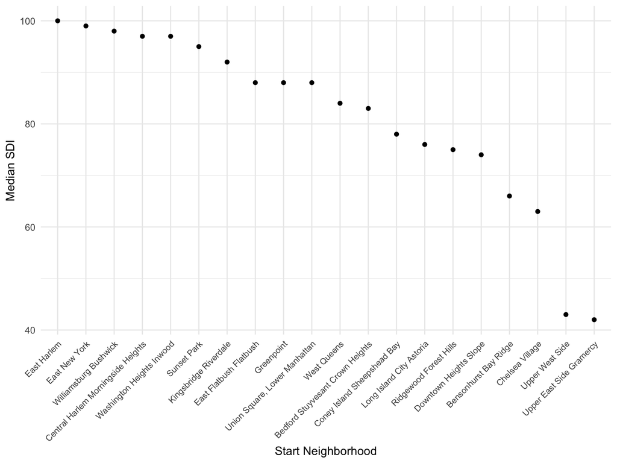

```r
plot = citibike_df |>
  group_by(start_uhf34_neighborhood) |>
  summarize(median_SDI = median(start_sdi_score)) |>
ggplot(aes(x = reorder(start_uhf34_neighborhood, -median_SDI), y = median_SDI,)) +
  geom_point() +
  theme_minimal() +
  theme(axis.text.x = element_text(angle = 45, hjust = 1, size = 8)) +
  labs(x = "Start Neighborhood", y = "Median SDI")

print(plot)
```